# SEA rsfcMRI - Longitudinal Descriptives

John Flournoy

2020-07-22

# Load the data

Starting with the Schaefer 400-parcel, 7 network atlas.

```r
#This should be easy to generalize
#option to set directory and search path
#option to rad in label file

library(data.table)
library(tidyr)
if(is.na(ncores <- as.numeric(Sys.getenv('SLURM_CPUS_ON_NODE')))){
  ncores <- 8
  message('No environment variable specifying number of cores. Setting to ', ncores, '.')
}
setDTthreads(ncores)

fname <- 'sea_rsfc_schaefer400x7.RDS'
if(file.exists(fname)){
  adt_labels <- readRDS(fname)
} else {
  data_dir <- '/net/holynfs01/srv/export/mclaughlin/share_root/stressdevlab/SEA_BIDS/derivatives/1.4.1-final/xcpengine-default'
  subs <- sprintf('sub-10%02d', c(1:16,18:31))
  sess <- sprintf('ses-%02d', 1:10)
  subses <- expand.grid(sess, subs)
  files <- paste0(data_dir, '/', subses[,2], '/', subses[,1], '/fcon/schaefer400x7/', subses[,2], '_', subses[,1], '_schaefer400x7.net')
  file_id <- paste0(subses[,2], '_', subses[,1])

  message('Creating file list...')
  files_list <- lapply(files, function(x) ifelse(file.exists(x), x, ''))

  message('Reading rsfc files...')
  if(ncores > 1){
    message('Using ', ncores, ' cores to read files.')
    cl <- parallel::makePSOCKcluster(ncores)

    adt_list <- unlist(parallel::parLapply(cl = cl, split(files, 1:ncores), function(part){
      lapply(part, function(f){
        if(file.exists(f)){
          data.table::fread(f, skip = 2, col.names = c('node1', 'node2', 'r'))
        } else {
          data.table::data.table()
        }
      })
    }), recursive = FALSE)
    try(stop(cl))
  } else {
    adt_list <- lapply(files, function(f){
      if(file.exists(f)){
        data.table::fread(f, skip = 2, col.names = c('node1', 'node2', 'r'))
      } else {
        data.table::data.table()
      }
    })
  }
  names(adt_list) <- file_id

  message('Combining data, assigning labels...')
  adt <- rbindlist(adt_list, idcol = 'id')

  #https://github.com/ThomasYeoLab/CBIG/tree/master/stable_projects/brain_parcellation/Schaefer2018_LocalGlobal/Parcellations/MNI
  schaefer_400_7_net_ids <- fread('Schaefer2018_400Parcels_7Networks_order.txt',
                                  col.names = c('node1', 'network1', 'V1', 'V2', 'V3', 'V4'))
  schaefer_400_7_net_ids[, c('V1', 'V2', 'V3', 'V4') := NULL]
  schaefer_400_7_net_ids <- schaefer_400_7_net_ids %>%
    tidyr::extract(network1, c('network1', 'roi1'), '7Networks_([RL]H_.*)_(\\d+)')

  setkey(adt, node1)
  setkey(schaefer_400_7_net_ids, node1)
  adt_labels1 <- schaefer_400_7_net_ids[adt]
  setnames(schaefer_400_7_net_ids, c('node2', 'network2', 'roi2'))
  setkey(adt_labels1, node2)
  setkey(schaefer_400_7_net_ids, node2)
  adt_labels <- schaefer_400_7_net_ids[adt_labels1]
  adt_labels[, c('id', 'sess') := tstrsplit(id, '_', fixed = TRUE)]
  message('Saving RDS file to: ', fname)
  saveRDS(adt_labels, fname)
}
```

Retain just within-network connectivity. Also, Fisher-z transform the correlations for analyses. One small detail that is important here is that we keep network connectivity for same-hemisphere parcels only.

```r
sea_schaefer400_7_withinnet <- copy(adt_labels)

sub_regex <- '[LR]H_[A-Za-z]+_*(.*)'
net_regex <- '[LR]H_([A-Za-z]+)_*(?:.*)'
hem_regex <- '([LR]H)_[A-Za-z]+_*(?:.*)'
sea_schaefer400_7_withinnet_nets <- distinct(sea_schaefer400_7_withinnet, network1)
sea_schaefer400_7_withinnet_nets[, sub1 := gsub(sub_regex, '\\1', network1)]
sea_schaefer400_7_withinnet_nets[, net1 := gsub(net_regex, '\\1', network1)]
sea_schaefer400_7_withinnet_nets[, hem1 := gsub(hem_regex, '\\1', network1)]
setkey(sea_schaefer400_7_withinnet, network1)
setkey(sea_schaefer400_7_withinnet_nets, network1)
sea_schaefer400_7_withinnet <- sea_schaefer400_7_withinnet_nets[sea_schaefer400_7_withinnet]

setnames(sea_schaefer400_7_withinnet_nets, c('network2', 'sub2', 'net2', 'hem2'))
setkey(sea_schaefer400_7_withinnet, network2)
setkey(sea_schaefer400_7_withinnet_nets, network2)
sea_schaefer400_7_withinnet <- sea_schaefer400_7_withinnet_nets[sea_schaefer400_7_withinnet]

sea_schaefer400_7_withinnet <- sea_schaefer400_7_withinnet[net1 == net2 & hem1 == hem2]
sea_schaefer400_7_withinnet[, c('network1', 'network2') := NULL]
sea_schaefer400_7_withinnet[, z := atanh(r)]
sea_schaefer400_7_withinnet[, H := dplyr::case_when(hem1 == 'RH' ~ -1,
                                                    hem1 == 'LH' ~ 1)]
if(!dim(distinct(sea_schaefer400_7_withinnet, net1, net2, hem1, hem2))[[1]] == 14){
  stop('Incorrect number of networks')
}
```

# Some QC

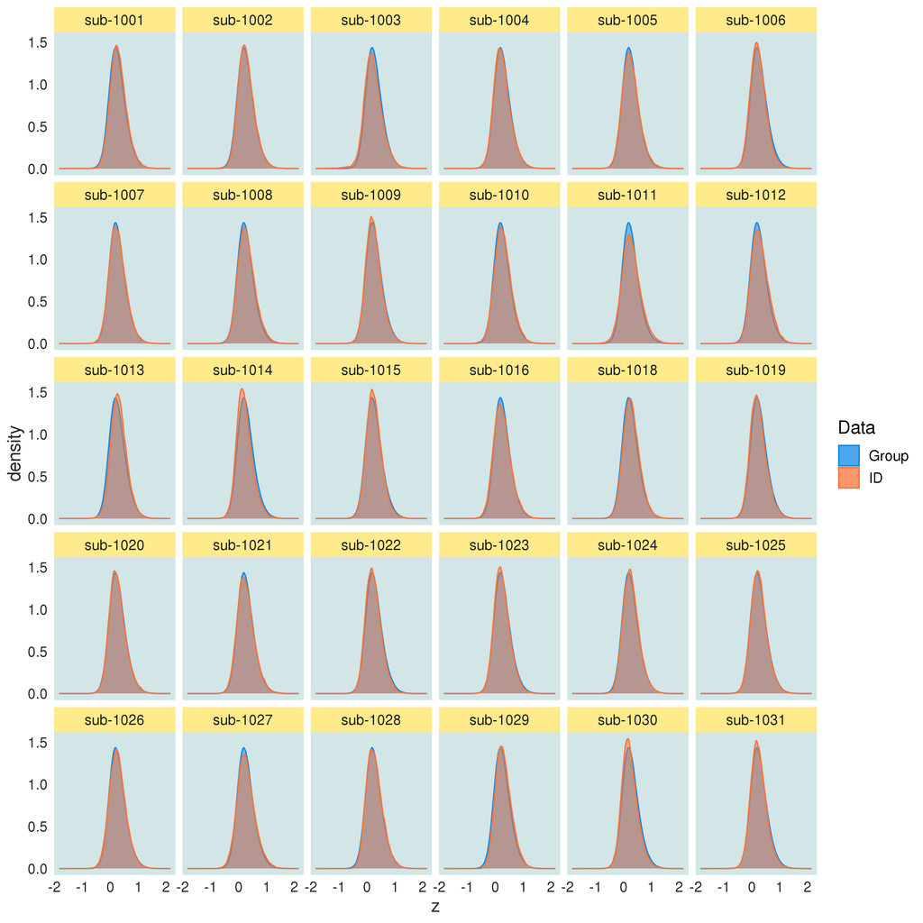

```r
hist_plot_fname <- 'hist_plot.png'
if(!file.exists(hist_plot_fname)){
  hist_plot <- ggplot(sea_schaefer400_7_withinnet, aes(x = z)) +
    geom_density(data = sea_schaefer400_7_withinnet[,'z'], aes(fill = 'Group', color = 'Group'), alpha = .5) +
    geom_density(aes(fill = 'ID', color = 'ID'), alpha = .5) +
    scale_fill_manual(aesthetics = c('color','fill'), breaks = c('Group', 'ID'), labels = c('Group', 'ID'), values = apal[c(4,2)], name = 'Data') +
    facet_wrap(~id) +
    jftheme

  ggsave(hist_plot_fname, hist_plot)
}
knitr::include_graphics(hist_plot_fname)
```

# Modeling

We are interested in stability and variability for each network. For each participant, we have multiple sessions, and within each session, we have multiple parcel-parcel pairs that provide information about the within-network connectivity. We can use the fact that we have multiple indicators of within-network connectivity to estimate the between-person variability, as well as the within-person (session-to-session) variability as distinct from measurement error (we assume that each parcel-parcel functional connectivity estimate in a network is an estimate of that network’s connectivity)*.

* This assumption means that we essentially treat differences in the FC between one pair and another as measurement error.

$$\begin{align}
z &= \beta_{0jk} + \beta_{1jk}\text{H}_{ijk} + \epsilon_{ijk} \\
\beta_{0jk} &= \pi_{00k} + \nu_{0jk} \\
\beta_{1jk} &= \pi_{10k} + \nu_{1jk} \\
\pi_{00k} &= \gamma_{000} + \upsilon_{00k} \\
\pi_{10k} &= \gamma_{100} + \upsilon_{10k}
\end{align}$$

$$\begin{align}
z = &\gamma_{000} + \upsilon_{00k} + \nu_{0jk} + \\
&(\gamma_{100} + \upsilon_{10k} + \nu_{1jk})\text{H}_{ijk} + \\
&\epsilon_{ijk}
\end{align}$$
Where $z$ is the measure of functional connectivity, and $i$ indexes observations within each session, $j$, for each participant $k$. This means that we are able to estimate variance in per-person deviations ($\upsilon_{00k}$) from the network mean-connectivity ($\gamma_{000}$), per-session-deviations ($\nu_{0jk}$) from those per-person deviations, and the residual not explained by variability over persons or person-sessions ($\epsilon_{ijk}$). All these are adjusted by the the effect of hemisphere at every level.

## Testing these out

I want to make sure that these models are correct, so I’ll compare the variance portions, and total variance, between the two models.

```r
library(lme4)
networks <- unique(sea_schaefer400_7_withinnet$net1)
this_net <- networks[[2]]
this_net_dt <- sea_schaefer400_7_withinnet[net1 == this_net]

model_dir <- 'models'
test_model_list <- list(test_2l = list(fn = file.path(model_dir, 'test_2l.RDS'),
                                         form = z ~ 1 + H + (1 + H || id)),
                          test_3l = list(fn = file.path(model_dir, 'test_3l.RDS'),
                                         form = z ~ 1 + H + (1 + H || id/sess)),
                          test_3l_noh = list(fn = file.path(model_dir, 'test_3l_noh.RDS'),
                                             form = z ~ 1 + (1 | id/sess)))
cl <- parallel::makePSOCKcluster(ncores - 1)

test_model_fits <- parallel::parLapply(cl = cl, test_model_list, function(model_list, d){
  library(lme4)
  if(!file.exists(model_list[['fn']])){
    f <- model_list[['form']]
    fit <- lmer(f, data = d)
    saveRDS(fit, model_list[['fn']])
  } else {
    fit <- readRDS(model_list[['fn']])
  }
  return(fit)
}, d = this_net_dt)

try(parallel::stopCluster(cl))
```

```r
three_level <- test_model_fits$test_3l
three_level_noh <- test_model_fits$test_3l_noh

summary(three_level)
```

```
## Linear mixed model fit by REML ['lmerMod']
## Formula: z ~ 1 + H + ((1 | id/sess) + (0 + H | id/sess))
##    Data: d
##
## REML criterion at convergence: 182855.8
##
## Scaled residuals:
##     Min      1Q  Median      3Q     Max
## -4.8260 -0.6863 -0.0761  0.6112  6.0690
##
## Random effects:
##  Groups    Name        Variance  Std.Dev.
##  sess.id   H           5.427e-04 0.023296
##  sess.id.1 (Intercept) 3.114e-03 0.055802
##  id        H           1.334e-04 0.011551
##  id.1      (Intercept) 6.391e-05 0.007994
##  Residual              7.966e-02 0.282237
## Number of obs: 587200, groups:  sess:id, 289; id, 30
##
## Fixed effects:
##             Estimate Std. Error t value
## (Intercept) 0.218603   0.003614  60.484
## H           0.002104   0.002546   0.826
##
## Correlation of Fixed Effects:
##   (Intr)
## H -0.005
## convergence code: 0
## Model failed to converge with max|grad| = 0.00602013 (tol = 0.002, component 1)
```

```r
summary(three_level_noh)
```

```
## Linear mixed model fit by REML ['lmerMod']
## Formula: z ~ 1 + (1 | id/sess)
##    Data: d
##
## REML criterion at convergence: 186542
##
## Scaled residuals:
##     Min      1Q  Median      3Q     Max
## -4.8941 -0.6869 -0.0774  0.6111  6.0356
##
## Random effects:
##  Groups   Name        Variance  Std.Dev.
##  sess:id  (Intercept) 3.193e-03 0.056508
##  id       (Intercept) 6.238e-06 0.002498
##  Residual             8.027e-02 0.283317
## Number of obs: 587200, groups:  sess:id, 289; id, 30
##
## Fixed effects:
##             Estimate Std. Error t value
## (Intercept) 0.219509   0.003376   65.03
```

```r
lll_varcorr <- VarCorr(three_level)
lll_varcorr_noh <- VarCorr(three_level_noh)

report_df <- data.frame(
  stat = c('id_var', 'sess_var', 'resid_var', 'total_var'),
  three_level = c(lll_varcorr$id.1['(Intercept)','(Intercept)'],
                  lll_varcorr$sess.id.1['(Intercept)','(Intercept)'],
                  sigma(three_level)^2,
                  sum(unlist(lapply(lll_varcorr, diag))) + sigma(three_level)^2),
  three_level_noh = c(lll_varcorr_noh$id['(Intercept)','(Intercept)'],
                      lll_varcorr_noh$`sess:id`['(Intercept)','(Intercept)'],
                      sigma(three_level_noh)^2,
                      sum(unlist(lapply(lll_varcorr_noh, diag))) + sigma(three_level_noh)^2))

report_df$three_level_perc <- report_df$three_level_noh/report_df$three_level_noh[[4]]*100
report_df$three_level_noh_perc <- report_df$three_level_noh/report_df$three_level_noh[[4]]*100
knitr::kable(report_df, digits = 5)
```

| stat | three_level | three_level_noh | three_level_perc | three_level_noh_perc |
| --- | --- | --- | --- | --- |
| id_var | 0.00006 | 0.00001 | 0.00747 | 0.00747 |
| sess_var | 0.00311 | 0.00319 | 3.82556 | 3.82556 |
| resid_var | 0.07966 | 0.08027 | 96.16696 | 96.16696 |
| total_var | 0.08351 | 0.08347 | 100.00000 | 100.00000 |